# Best Tree

MYC

11/14/2021

Path to data

```r
#note the use of the here() package and not absolute paths
data_location <- here::here("data","processed_data","P2-20211029.rds")
#read and load data.
```

Import P2 data

```r
P2<- readRDS(data_location)
```

Add to the data – Fix so we add a catagorical aspect to Ct values- simplicity make Detected/Yes (< 37.9) and Undetected/No (>38)

Bonus- try to figure out how to change into 3 levels?

```r
P2.Plus.Cat<-
  P2%>%
  mutate(
# if greater than ct 38, this is a negative detection, thus less 38 is a positive in detection
    Ct.Cat = ifelse(Ct >=38,"No","Yes"),
# There are some NAs, they are undetectable, change only in the Ct.Cat to No as a factor
    Ct.Cat=ifelse(is.na(Ct.Cat), "No",Ct.Cat),
# These are factors so mutate the chr to fctrs
    Ct.Cat=factor(Ct.Cat)
    )%>%
#Remove/adjust so there are no character based factors
    select(PCR, RH,TEMP, Method, Tool, Input, Detector, Ct, Ct.Cat)%>%
  na.omit()

summary(P2.Plus.Cat)
```

```
##      PCR                  RH             TEMP       Method          Tool
##  Length:382         Min.   :38.70   Min.   :24.83   CDC: 97   A       :143
##  Class :character   1st Qu.:38.70   1st Qu.:24.83   NTP:285   B       :124
##  Mode  :character   Median :41.20   Median :25.15   PCR:  0   SD      : 92
##                     Mean   :40.58   Mean   :25.23             POS.CTRL: 23
##                     3rd Qu.:42.05   3rd Qu.:25.70                     :  0
##                     Max.   :42.05   Max.   :25.70             NEG.CTRL:  0
##                                                               (Other) :  0
##      Input          Detector         Ct        Ct.Cat
##  Min.   : 300   N1 Probe:188   Min.   :16.59   No : 11
##  1st Qu.: 300   N2 Probe:194   1st Qu.:24.97   Yes:371
##  Median : 300                  Median :27.49
##  Mean   :1795                  Mean   :28.41
##  3rd Qu.:1000                  3rd Qu.:32.62
##  Max.   :7000                  Max.   :44.00
##
```

Set Seed for reproducibility

```r
# Fix the random numbers by setting the seed
set.seed(123)
# This enables the analysis to be reproducible when random numbers are used
```

1. Data splitting into training and testing sets (Random sampling)
2. Training
3. Testing

```r
# Put 3/4 of the data into the training set; this leaves 1/4 of the data to be used to test
data_split <- initial_split(P2.Plus.Cat, prop = 3/4)

## Create data frames for the two sets:
train_data <- training(data_split)
test_data  <- testing(data_split)
```

```r
#View the train and test data
glimpse(train_data)
```

```
## Rows: 286
## Columns: 9
## $ PCR      <chr> "10/5/2021", "9/30/2021", "10/5/2021", "10/22/2021", "9/30/20~
## $ RH       <dbl> 42.05, 41.20, 42.05, 38.70, 41.20, 38.70, 42.05, 42.05, 38.70~
## $ TEMP     <dbl> 25.15, 25.70, 25.15, 24.83, 25.70, 24.83, 25.15, 25.15, 24.83~
## $ Method   <fct> NTP, CDC, NTP, NTP, NTP, CDC, NTP, NTP, NTP, NTP, NTP, NTP, N~
## $ Tool     <fct> A, A, A, A, B, B, A, B, B, A, A, A, SD, B, A, B, SD, SD, A, A~
## $ Input    <dbl> 300, 300, 1000, 300, 1000, 300, 1000, 6900, 6900, 300, 6900, ~
## $ Detector <fct> N2 Probe, N1 Probe, N1 Probe, N2 Probe, N2 Probe, N2 Probe, N~
## $ Ct       <dbl> 29.4977, 27.0894, 28.1237, 27.2572, 32.2346, 34.7261, 27.9466~
## $ Ct.Cat   <fct> Yes, Yes, Yes, Yes, Yes, Yes, Yes, Yes, Yes, Yes, Yes, Yes, Y~
```

```r
glimpse(test_data)
```

```
## Rows: 96
## Columns: 9
## $ PCR      <chr> "9/30/2021", "9/30/2021", "9/30/2021", "9/30/2021", "9/30/202~
## $ RH       <dbl> 41.2, 41.2, 41.2, 41.2, 41.2, 41.2, 41.2, 41.2, 41.2, 41.2, 4~
## $ TEMP     <dbl> 25.7, 25.7, 25.7, 25.7, 25.7, 25.7, 25.7, 25.7, 25.7, 25.7, 2~
## $ Method   <fct> CDC, CDC, NTP, NTP, CDC, CDC, CDC, CDC, NTP, NTP, CDC, CDC, C~
## $ Tool     <fct> SD, SD, SD, SD, A, B, B, B, A, B, POS.CTRL, A, A, B, A, A, A,~
## $ Input    <dbl> 300, 300, 300, 300, 300, 300, 300, 300, 300, 300, 300, 300, 3~
## $ Detector <fct> N1 Probe, N1 Probe, N1 Probe, N1 Probe, N1 Probe, N1 Probe, N~
## $ Ct       <dbl> 26.7697, 25.0061, 27.0992, 20.1800, 27.1725, 33.8846, 33.1872~
## $ Ct.Cat   <fct> Yes, Yes, Yes, Yes, Yes, Yes, Yes, Yes, Yes, Yes, Yes, Yes, Y~
```

2. Creating Models

# Ct value or Detection as function of method and inital dilution

Detection ~ Model + Dilution

# Ct value or detection for all precitcors (short hand for all predictors)

Detection~., data=P2.Plus.Cat

2.1. Many engines Examples

```r
# fit linear model
lm_lm    <- lm(Ct ~ ., data = P2.Plus.Cat)
# fit general linear model
lm_glm   <- glm(Ct ~ ., data = P2.Plus.Cat,
                family = gaussian)
#########
#<atempt to use later>
# meta engine (aggregator) method=<method name>; see parsnips
#lm_caret <- train(Ct ~ ., data = P2.Plus.Cat,
#                 method = "glm")
```

2.4. Resampling - CV

```r
# create CV object from training data
cv_data <- rsample::vfold_cv(train_data, v = 5, repeats = 5, strata = 'Ct')

print(cv_data)
```

```
## #  5-fold cross-validation repeated 5 times using stratification
## # A tibble: 25 x 3
##    splits           id      id2
##    <list>           <chr>   <chr>
##  1 <split [226/60]> Repeat1 Fold1
##  2 <split [228/58]> Repeat1 Fold2
##  3 <split [230/56]> Repeat1 Fold3
##  4 <split [230/56]> Repeat1 Fold4
##  5 <split [230/56]> Repeat1 Fold5
##  6 <split [226/60]> Repeat2 Fold1
##  7 <split [228/58]> Repeat2 Fold2
##  8 <split [230/56]> Repeat2 Fold3
##  9 <split [230/56]> Repeat2 Fold4
## 10 <split [230/56]> Repeat2 Fold5
## # ... with 15 more rows
```

```r
############## below are similar functions but need to try

#apply CV in ML algorithm to process the ML model to each resample
vfold_cv(P2.Plus.Cat, v=5)
```

```
## #  5-fold cross-validation
## # A tibble: 5 x 2
##   splits           id
##   <list>           <chr>
## 1 <split [305/77]> Fold1
## 2 <split [305/77]> Fold2
## 3 <split [306/76]> Fold3
## 4 <split [306/76]> Fold4
## 5 <split [306/76]> Fold5
```

```r
#bootstrapping- random sample of data with replacment
bootstraps(P2.Plus.Cat, v=5)
```

```
## # Bootstrap sampling
## # A tibble: 25 x 2
##    splits            id
##    <list>            <chr>
##  1 <split [382/136]> Bootstrap01
##  2 <split [382/133]> Bootstrap02
##  3 <split [382/144]> Bootstrap03
##  4 <split [382/139]> Bootstrap04
##  5 <split [382/139]> Bootstrap05
##  6 <split [382/132]> Bootstrap06
##  7 <split [382/148]> Bootstrap07
##  8 <split [382/136]> Bootstrap08
##  9 <split [382/149]> Bootstrap09
## 10 <split [382/138]> Bootstrap10
## # ... with 15 more rows
```

Preprocessing Using parsnims to create a recipe for fitting the model No standardization adding dummy variables are added

```r
fit_recipe <-
# set a recipe
  recipe(Ct ~ ., data = P2.Plus.Cat) %>%
# code all categorical variables as dummy variables
  step_dummy(all_nominal())

print(fit_recipe)
```

```
## Recipe
##
## Inputs:
##
##       role #variables
##    outcome          1
##  predictor          8
##
## Operations:
##
## Dummy variables from all_nominal()
```

Null Model Ct is a continuions outcome of numbers– need to use RMSE as performance metric.

```r
RMSE_null_train <- sqrt(sum( (train_data$Ct - mean(train_data$Ct))^2 )/nrow(train_data))

RMSE_null_test <- sqrt(sum( (test_data$Ct - mean(test_data$Ct))^2 )/nrow(test_data))

print(RMSE_null_train)
```

```
## [1] 5.163031
```

```r
#predict(lm_lm, train_data=Ct)
```

2.5. Hyper parameter tuning

2.6. Model evaluation - Regression - minimize - MSE - RMSE - Deviance - MAE - RMSLE - maximize - R^2 - classification - minimize - Misclassifcation - Mean per class e rror - MSE - Cross-entropy – log loss/deviance - Gini index - maximize - Accuracy - Precision - Sensitivity / recall - Specificity - AUC

Tree model

```r
tree_model <-  decision_tree() %>%
  set_args( cost_complexity = tune(), tree_depth = tune(), min_n = tune()) %>%
  set_engine("rpart") %>%
  set_mode("regression")
```

Workflow

```r
#set workflow
tree_wf <- workflow() %>%
  add_model(tree_model) %>%
  add_recipe(fit_recipe)
```

Tree Model

```r
#tuning grid
tree_grid <- dials::grid_regular(cost_complexity(), tree_depth(), min_n(), levels = 5)
#tune the model
tree_tune_res <- tree_wf %>%
  tune::tune_grid(
    resamples = cv_data,
    grid = tree_grid,
    metrics = yardstick::metric_set(rmse)
  )
```

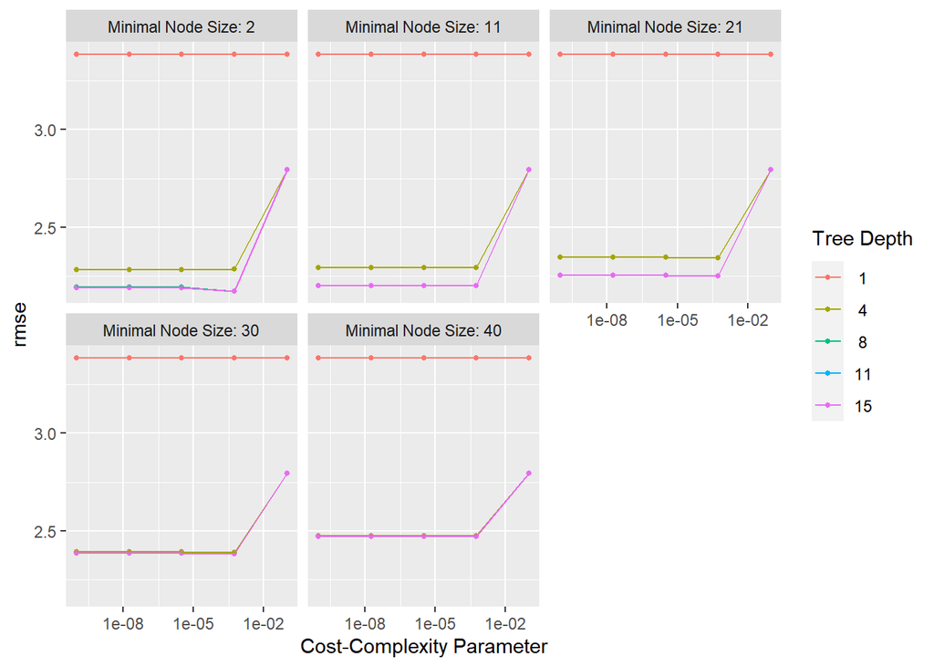

```r
#see a plot of performance for different tuning parameters
tree_tune_res %>% autoplot()
```

```r
# get the tuned model that performs best
best_tree <- tree_tune_res %>%  select_best(metric = "rmse")
# finalize workflow with best model
best_tree_wf <- tree_wf %>% finalize_workflow(best_tree)
# fitting best performing model
best_tree_fit <- best_tree_wf %>%
                 fit(data = train_data)
#predicting outcomes for final model
tree_pred <- predict(best_tree_fit, train_data)
```

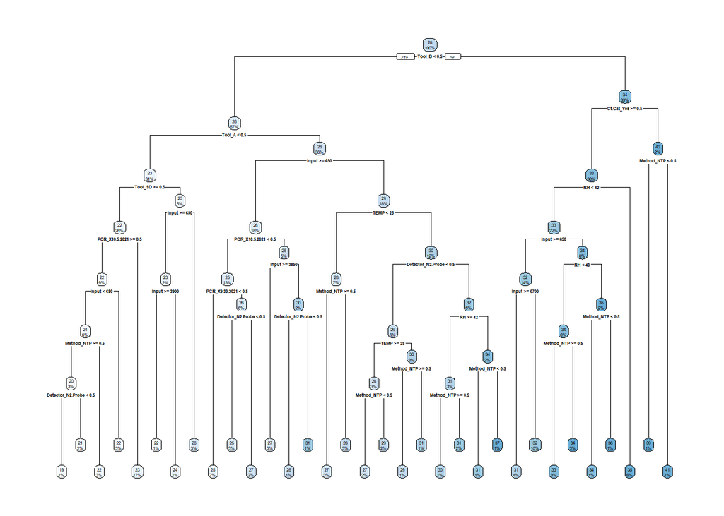

```r
rpart.plot(extract_fit_parsnip(best_tree_fit)$fit)
```

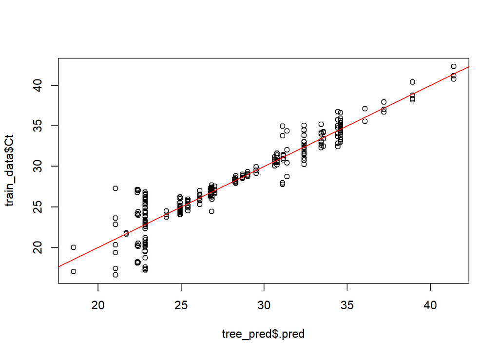

```r
#predicted versus observed
plot(tree_pred$.pred,train_data$Ct)
abline(a=0,b=1, col = 'red') #45 degree line, along which the results should fall
```

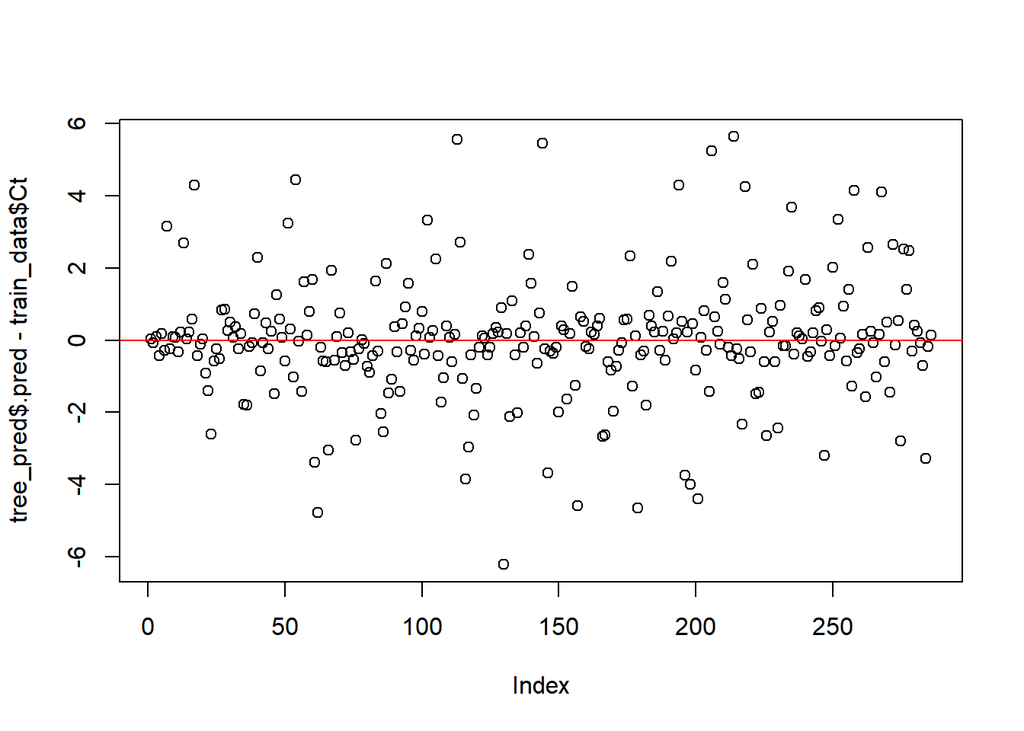

```r
#residuals
plot(tree_pred$.pred-train_data$Ct)
abline(a=0,b=0, col = 'red') #straight line, along which the results should fall
```

```r
tree_perfomance <- tree_tune_res %>% show_best(n = 5)
print(tree_perfomance)
```

```
## # A tibble: 5 x 9
##   cost_complexity tree_depth min_n .metric .estimator  mean     n std_err
##             <dbl>      <int> <int> <chr>   <chr>      <dbl> <int>   <dbl>
## 1      0.000562           11     2 rmse    standard    2.17    25  0.0610
## 2      0.000562           15     2 rmse    standard    2.17    25  0.0610
## 3      0.000562            8     2 rmse    standard    2.17    25  0.0609
## 4      0.00000316         11     2 rmse    standard    2.19    25  0.0599
## 5      0.00000316         15     2 rmse    standard    2.19    25  0.0599
## # ... with 1 more variable: .config <chr>
```